# Virginia Schools Pre- & Post-Pandemic

Cassandra Sperow

Updated 9-18-2022

# Exploration of Pre- & Post-Pandemic Pass Rate Scores from the Standards of Learning (SOL) Test Results of Schools in the State of Virginia, USA

- A previous version of sorts for Fairfax County is also available in this repo.
- This analysis is for my own curiosity and should not be construed as anything extensive in regards to judging schools or judging how good a school may be. There are too many factors and circumstances that go into what makes a good school.

## Original public data source:

[Virginia Department of Education SOL Test Results](https://www.doe.virginia.gov/statistics_reports/sol-pass-rates/index.shtml)

### Import Libraries

```r
library(tidyverse)
```

### Import Data

```r
schools_raw <- read_csv("../data/2020-2021-school-test-by-test.csv", skip =2)
schools_raw %>% head
```

```
## # A tibble: 6 × 17
##   LEVEL `Div Num` Div Na…¹ Sch N…² Sch N…³ Sch T…⁴ Low G…⁵ High …⁶ Subject Grade
##   <chr>     <dbl> <chr>      <dbl> <chr>   <chr>   <chr>     <dbl> <chr>   <chr>
## 1 SCH           1 Accomac…     701 Accawm… Elem    PK            5 Englis… Gr 3
## 2 SCH           1 Accomac…     701 Accawm… Elem    PK            5 Englis… Gr 4
## 3 SCH           1 Accomac…     701 Accawm… Elem    PK            5 Englis… Gr 5
## 4 SCH           1 Accomac…     701 Accawm… Elem    PK            5 Mathem… Gr 3
## 5 SCH           1 Accomac…     701 Accawm… Elem    PK            5 Mathem… Gr 4
## 6 SCH           1 Accomac…     701 Accawm… Elem    PK            5 Mathem… Gr 5
## # … with 7 more variables: Test <chr>, `2018-2019 Pass Rate` <chr>,
## #   `2019-2020 Pass Rate` <lgl>, `2020-2021 Pass Rate` <chr>,
## #   `2018-2019 Adv Pass Rate` <chr>, `2019-2020 Adv Pass Rate` <lgl>,
## #   `2020-2021 Adv Pass Rate` <chr>, and abbreviated variable names
## #   ¹`Div Name`, ²`Sch Num`, ³`Sch Name`, ⁴`Sch Type`, ⁵`Low Grade`,
## #   ⁶`High Grade`
```

```r
nrow(schools_raw) # 14,381
```

```
## [1] 14381
```

### Checking columns where pass rate should have been a number

```r
# There is a "<" character that needs to be counted as NA
schools_raw$`2018-2019 Pass Rate` %>% unique()
```

```
##  [1] "57"  "74"  "60"  "73"  "80"  "84"  "79"  "78"  "96"  "77"  "72"  "64"
## [13] "69"  "65"  "81"  "100" "85"  "76"  "92"  "93"  "94"  "86"  "82"  "89"
## [25] "88"  "91"  "<"   "55"  "62"  "44"  "54"  "67"  "58"  "61"  "90"  "83"
## [37] "71"  "70"  "68"  "75"  "50"  "42"  "33"  "87"  "66"  NA    "52"  "99"
## [49] "97"  "98"  "48"  "63"  "59"  "95"  "53"  "47"  "56"  "6"   "35"  "51"
## [61] "43"  "49"  "45"  "40"  "46"  "32"  "26"  "29"  "39"  "41"  "11"  "30"
## [73] "10"  "34"  "27"  "22"  "25"  "38"  "23"  "13"  "19"  "14"  "28"  "8"
## [85] "15"  "37"  "21"  "20"  "36"  "31"  "18"  "24"  "17"
```

### Mutating pass rate columns into number columns with new NA definition to include the character “<”

- Also changing the school type column to a categorical variable and renaming it in one mutate()

```r
# setting the NA values to include "<" because there was not a value given or key for what the "<" indicates
schools_raw %>%
  mutate(sch_type = parse_factor(`Sch Type`)) %>%
  mutate(pass_rate_18_19 = parse_integer(`2018-2019 Pass Rate`,
                                         na = c("", "NA", NA, "<"),
                                         trim_ws = TRUE),
         pass_rate_20_21 = parse_integer(`2020-2021 Pass Rate`,
                                         na = c("", "NA", NA, "<"),
                                         trim_ws = TRUE),
         county = `Div Name`) -> schools

# checking to make sure they're all numbers
filter(schools, is.character(pass_rate_20_21))
```

```
## # A tibble: 0 × 21
## # … with 21 variables: LEVEL <chr>, Div Num <dbl>, Div Name <chr>,
## #   Sch Num <dbl>, Sch Name <chr>, Sch Type <chr>, Low Grade <chr>,
## #   High Grade <dbl>, Subject <chr>, Grade <chr>, Test <chr>,
## #   2018-2019 Pass Rate <chr>, 2019-2020 Pass Rate <lgl>,
## #   2020-2021 Pass Rate <chr>, 2018-2019 Adv Pass Rate <chr>,
## #   2019-2020 Adv Pass Rate <lgl>, 2020-2021 Adv Pass Rate <chr>,
## #   sch_type <fct>, pass_rate_18_19 <int>, pass_rate_20_21 <int>, …
```

### Calculating a Percent Change between school year 2018-2019 and 2020-2021.

Note: The Virginia Department of Education did not post any state assessment data for the school year 2019-2020 due to the cancellation of state assessments during the COVID-19 pandemic. See [here](https://doe.virginia.gov/statistics_reports/sol-pass-rates/index.shtml).

```r
schools %>%
  # selecting necessary columns rather than whole dataset
  select(county, sch_type, `Sch Name`, Test, Grade, pass_rate_18_19, pass_rate_20_21) %>%
  # calculating point difference between pre- and post-pandemic
  mutate(point_diff =  pass_rate_20_21 - pass_rate_18_19) %>%
  # creating percent change column
  mutate(pct_change = (point_diff/pass_rate_18_19)*100) %>%
  # changing into categorical variable
  mutate(Test = parse_factor(Test)) -> schools

schools %>% glimpse()
```

```
## Rows: 14,381
## Columns: 9
## $ county          <chr> "Accomack County", "Accomack County", "Accomack County…
## $ sch_type        <fct> Elem, Elem, Elem, Elem, Elem, Elem, Elem, High, High, …
## $ `Sch Name`      <chr> "Accawmacke Elementary", "Accawmacke Elementary", "Acc…
## $ Test            <fct> English Reading, English Reading, English Reading, Mat…
## $ Grade           <chr> "Gr 3", "Gr 4", "Gr 5", "Gr 3", "Gr 4", "Gr 5", "Gr 5"…
## $ pass_rate_18_19 <int> 57, 74, 60, 73, 80, 84, 79, 80, 78, 96, 77, 72, 60, 72…
## $ pass_rate_20_21 <int> 50, 56, 45, 38, 28, 34, 34, 74, 55, 67, 69, 50, 13, 85…
## $ point_diff      <int> -7, -18, -15, -35, -52, -50, -45, -6, -23, -29, -8, -2…
## $ pct_change      <dbl> -12.28070, -24.32432, -25.00000, -47.94521, -65.00000,…
```

## Basic Descriptive Stats

- How many unique schools?

```r
schools %>%
  summarise(`Sch Name`) %>%
  unique() %>%
  nrow
```

```
## [1] 1731
```

- How many county/city school districts within the State of Virginia?

```r
schools %>%
  summarise(county) %>%
  unique() %>%
  nrow()
```

```
## [1] 132
```

- How many schools per district? Which one has the most schools (ie, the largest)?

```r
schools %>%
  group_by(county, `Sch Name`) %>%
  summarise(county, `Sch Name`) %>%
  unique() %>%
  group_by(county) %>%
  summarise(count = n()) %>%
  arrange(-count)
```

```
## # A tibble: 132 × 2
##    county                count
##    <chr>                 <int>
##  1 Fairfax County          194
##  2 Loudoun County           93
##  3 Prince William County    92
##  4 Virginia Beach City      81
##  5 Henrico County           66
##  6 Chesterfield County      62
##  7 Richmond City            44
##  8 Norfolk City             42
##  9 Chesapeake City          38
## 10 Newport News City        37
## # … with 122 more rows
```

- What are the categories of schools?

```r
schools %>%
  summarise(sch_type) %>%
  unique()
```

```
## # A tibble: 4 × 1
##   sch_type
##   <fct>
## 1 Elem
## 2 High
## 3 Middle
## 4 Combined
```

- What are the Test categories?

```r
schools$Test %>% levels()
```

```
## [1] "English Reading" "Mathematics"     "Science"         "Algebra I"
## [5] "Algebra II"      "Geometry"        "Biology"         "Chemistry"
## [9] "Earth Science"
```

### Distribution of 2018-2019 Pass Rates for All Schools

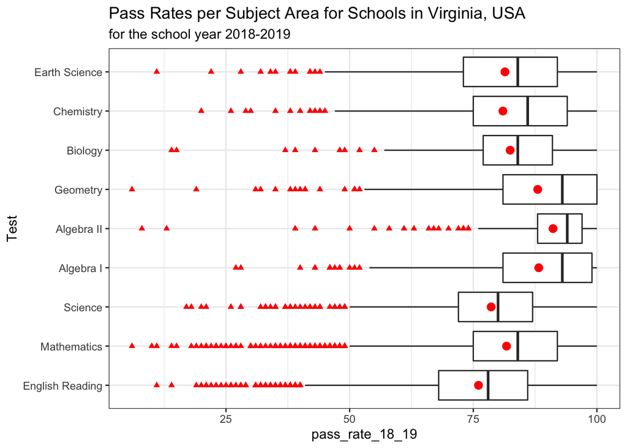

```r
schools %>%
  ggplot(aes(x = pass_rate_18_19, y = Test)) +
  geom_boxplot(outlier.shape = "triangle", outlier.color = "red") +
  theme_bw() +
  stat_summary(fun = mean, color = "red") +
  ggtitle("Pass Rates per Subject Area for Schools in Virginia, USA",
          subtitle = "for the school year 2018-2019")
```

Key:

- The triangles are considered outliers.
- The circles represent the mean (average) pass rate for that test subject area for the whole State of Virginia.
- The black lines inside each boxplot indicate the median pass rate.